# VAR_FinalProject

XiaoPang

2023-05-11

```r
file_path <- "E:/px/UChi/Courses/23S_TimeSeries/Project/trade/TS_Project.xlsx"
df <- read_excel(file_path, 'Chicago')
```

# train-test spilt

*pre-covid: 2002-2018 -> 2019* post-covid: 2002-2021 -> 2022

```r
test_start <- as.Date("2019-01-01")
test_end <- as.Date("2019-12-01")
df$time <- as.Date(df$time)

# Split data into training and test sets
df_train1 <- df %>% filter(time < test_start)
df_test1 <- df %>% filter(time >= test_start & time <= test_end)
tail(df_train1)
```

| time | export | import | cpi | ppi | bond | sentiment | USDX | uncertainty |
| --- | --- | --- | --- | --- | --- | --- | --- | --- |
| 2018-07-01 | 4.084457 | 17.25305 | 251.214 | 204.3 | 2.89 | 97.9 | 94.49 | 133.08625 |
| 2018-08-01 | 4.246205 | 17.32065 | 251.663 | 203.4 | 2.89 | 96.2 | 95.14 | 99.13562 |
| 2018-09-01 | 4.826638 | 16.45093 | 252.182 | 203.6 | 3.00 | 100.1 | 95.19 | 102.66020 |
| 2018-10-01 | 4.558926 | 20.25754 | 252.772 | 204.6 | 3.15 | 98.6 | 97.13 | 111.51257 |
| 2018-11-01 | 4.168730 | 18.04742 | 252.594 | 202.3 | 3.12 | 97.5 | 97.27 | 130.22387 |
| 2018-12-01 | 4.501756 | 15.89982 | 252.767 | 201.0 | 2.83 | 98.3 | 96.17 | 166.28681 |

```r
head(df_test1)
```

| time | export | import | cpi | ppi | bond | sentiment | USDX | uncertainty |
| --- | --- | --- | --- | --- | --- | --- | --- | --- |
| 2019-01-01 | 3.611883 | 15.09622 | 252.718 | 199.1 | 2.71 | 91.2 | 95.58 | 201.0320 |
| 2019-02-01 | 3.589871 | 13.30418 | 253.322 | 199.2 | 2.68 | 93.8 | 96.16 | 106.9007 |
| 2019-03-01 | 4.771776 | 16.18607 | 254.202 | 200.8 | 2.57 | 98.4 | 97.28 | 140.2474 |
| 2019-04-01 | 3.898282 | 16.83041 | 255.211 | 202.1 | 2.53 | 97.2 | 97.48 | 98.7367 |
| 2019-05-01 | 4.369095 | 17.13831 | 255.290 | 201.7 | 2.40 | 100.0 | 97.75 | 122.5388 |
| 2019-06-01 | 4.608336 | 17.08137 | 255.159 | 200.3 | 2.07 | 98.2 | 96.13 | 150.1168 |

```r
# Split data into training and test sets
test_start <- as.Date("2022-01-01")
test_end <- as.Date("2022-12-01")
df_train2 <- df %>% filter(time < test_start)
df_test2 <- df %>% filter(time >= test_start & time <= test_end)
tail(df_train2)
```

| time | export | import | cpi | ppi | bond | sentiment | USDX | uncertainty |
| --- | --- | --- | --- | --- | --- | --- | --- | --- |
| 2021-07-01 | 5.054659 | 23.17660 | 271.764 | 231.850 | 1.32 | 81.2 | 92.17 | 152.9109 |
| 2021-08-01 | 4.753982 | 24.19342 | 272.870 | 233.415 | 1.28 | 70.3 | 92.63 | 133.8145 |
| 2021-09-01 | 5.510482 | 24.85819 | 274.028 | 235.678 | 1.37 | 72.8 | 94.25 | 142.0676 |
| 2021-10-01 | 6.068215 | 24.84563 | 276.522 | 240.465 | 1.58 | 71.7 | 94.12 | 121.9515 |
| 2021-11-01 | 6.278624 | 27.83137 | 278.711 | 243.287 | 1.56 | 67.4 | 95.99 | 151.2868 |
| 2021-12-01 | 6.986375 | 27.75879 | 280.887 | 241.338 | 1.47 | 70.6 | 95.67 | 166.2426 |

```r
head(df_test2)
```

| time | export | import | cpi | ppi | bond | sentiment | USDX | uncertainty |
| --- | --- | --- | --- | --- | --- | --- | --- | --- |
| 2022-01-01 | 5.692156 | 25.47443 | 282.599 | 246.453 | 1.76 | 67.2 | 96.54 | 139.2376 |
| 2022-02-01 | 6.323158 | 23.32638 | 284.610 | 252.660 | 1.93 | 62.8 | 96.71 | 138.0535 |
| 2022-03-01 | 6.956000 | 27.98500 | 287.472 | 260.014 | 2.13 | 59.4 | 98.31 | 190.0124 |
| 2022-04-01 | 5.371302 | 25.60838 | 288.611 | 265.310 | 2.75 | 65.2 | 102.96 | 154.6620 |
| 2022-05-01 | 6.232793 | 27.87424 | 291.268 | 273.251 | 2.90 | 58.4 | 101.75 | 168.0008 |
| 2022-06-01 | 5.844523 | 28.12850 | 294.728 | 280.251 | 3.14 | 50.0 | 104.69 | 145.9759 |

```r
dim(df_train1)
```

```
## [1] 204   9
```

```r
dim(df_test1)
```

```
## [1] 12  9
```

```r
dim(df_train2)
```

```
## [1] 240   9
```

```r
dim(df_test2)
```

```
## [1] 12  9
```

# stationary

**Since we should always stabilize the variance first** -> our only choice would be log first, then 1st diff

- adf test: p<0.05, stationary
- kpss test: p>0.05, stationary

```r
variable_names <- c("import", "export", "cpi", "ppi", "bond", "sentiment", "USDX", "uncertainty")
```

## pre covid

```r
# Create an empty matrix to store the p-values and significance
test_pre <- matrix(NA, nrow = length(variable_names),
                   ncol = 4)

# Perform ADF test for each variable's first-order difference
for (i in 1:length(variable_names)) {
  variable <- df_train1[[variable_names[i]]]
  variable_logdiff <- diff(log(variable))

  kpss_result_logdiff <- kpss.test(variable_logdiff)
  adf_result_logdiff <- adf.test(variable_logdiff, alternative = "stationary")

  adf_p_value <- adf_result_logdiff$p.value
  kpss_p_value <- kpss_result_logdiff$p.value

  adf_sig <- ifelse(adf_p_value < 0.05, "Stationary", "Not Stationary")
  kpss_sig <- ifelse(kpss_p_value > 0.05, "Stationary", "Not Stationary")

  test_pre[i, 1] <- adf_p_value
  test_pre[i, 2] <- adf_sig
  test_pre[i, 3] <- kpss_p_value
  test_pre[i, 4] <- kpss_sig
}

# Set the column names of the matrix
colnames(test_pre) <- c("adf.p.value", "adf.sig",
                        'kpss.p.value', 'kpss.sig')

# Set the row names of the matrix as the variable names
rownames(test_pre) <- variable_names

# Print the ADF test results for first-order differences
test_pre
```

```
##             adf.p.value adf.sig      kpss.p.value         kpss.sig
## import      "0.01"      "Stationary" "0.1"                "Stationary"
## export      "0.01"      "Stationary" "0.1"                "Stationary"
## cpi         "0.01"      "Stationary" "0.1"                "Stationary"
## ppi         "0.01"      "Stationary" "0.1"                "Stationary"
## bond        "0.01"      "Stationary" "0.1"                "Stationary"
## sentiment   "0.01"      "Stationary" "0.1"                "Stationary"
## USDX        "0.01"      "Stationary" "0.0550546563183358" "Stationary"
## uncertainty "0.01"      "Stationary" "0.1"                "Stationary"
```

## post covid

```r
# Create an empty matrix to store the p-values and significance
test_post <- matrix(NA, nrow = length(variable_names),
                   ncol = 4)

# Perform ADF test for each variable's first-order difference
for (i in 1:length(variable_names)) {
  variable <- df_train2[[variable_names[i]]]
  variable_logdiff <- diff(log(variable))

  kpss_result_logdiff <- kpss.test(variable_logdiff)
  adf_result_logdiff <- adf.test(variable_logdiff, alternative = "stationary")

  adf_p_value <- adf_result_logdiff$p.value
  kpss_p_value <- kpss_result_logdiff$p.value

  adf_sig <- ifelse(adf_p_value < 0.05, "Stationary", "Not Stationary")
  kpss_sig <- ifelse(kpss_p_value > 0.05, "Stationary", "Not Stationary")

  test_post[i, 1] <- adf_p_value
  test_post[i, 2] <- adf_sig
  test_post[i, 3] <- kpss_p_value
  test_post[i, 4] <- kpss_sig
}

# Set the column names of the matrix
colnames(test_post) <- c("adf.p.value", "adf.sig",
                        'kpss.p.value', 'kpss.sig')

# Set the row names of the matrix as the variable names
rownames(test_post) <- variable_names

# Print the ADF test results for first-order differences
test_post
```

```
##             adf.p.value adf.sig      kpss.p.value         kpss.sig
## import      "0.01"      "Stationary" "0.1"                "Stationary"
## export      "0.01"      "Stationary" "0.1"                "Stationary"
## cpi         "0.01"      "Stationary" "0.1"                "Stationary"
## ppi         "0.01"      "Stationary" "0.1"                "Stationary"
## bond        "0.01"      "Stationary" "0.1"                "Stationary"
## sentiment   "0.01"      "Stationary" "0.1"                "Stationary"
## USDX        "0.01"      "Stationary" "0.0768658750204772" "Stationary"
## uncertainty "0.01"      "Stationary" "0.1"                "Stationary"
```

**For both pre/post covid periods, log + 1st diff is enough to make all variables stationary.**

**Choose the same transformation method for all variables for better interpretability.**

## create stationary datasets

```r
# pre covid
train_pre <- data.frame(time = as.Date(df_train1$time[-1]))
for (variable in variable_names) {
  train_pre[[variable]] <- diff(log(df_train1[[variable]]))
}
colnames(train_pre) <- c("time", variable_names)
head(train_pre)
```

|  | time | import | export | cpi | ppi | bond | sentiment | USDX | uncertainty |
| --- | --- | --- | --- | --- | --- | --- | --- | --- | --- |
| 1 | 2002-02-01 | -0.01608281 | -0.04968509 | 0.0016868151 | -0.0007785131 | -0.026132140 | -0.02504214 | -0.009022567 | -0.28799478 |
| 2 | 2002-03-01 | 0.07607769 | 0.26966667 | 0.0028050509 | 0.0108444130 | 0.072652156 | 0.05366094 | -0.004542030 | -0.04865591 |
| 3 | 2002-04-01 | 0.15962455 | -0.18383664 | 0.0044717794 | 0.0076746348 | -0.013346242 | -0.02861881 | -0.029342175 | 0.05961620 |
| 4 | 2002-05-01 | -0.01960076 | 0.10679652 | 0.0011148273 | 0.0000000000 | -0.009643276 | 0.04108003 | -0.029781972 | -0.02593278 |
| 5 | 2002-06-01 | 0.02543645 | 0.07557858 | 0.0005569479 | 0.0007642339 | -0.045597591 | -0.04755254 | -0.052324683 | 0.08132318 |
| 6 | 2002-07-01 | 0.07054905 | -0.16063539 | 0.0022246950 | 0.0022892036 | -0.058471768 | -0.04765445 | 0.012177024 | 0.16411123 |

```r
dim(train_pre)
```

```
## [1] 203   9
```

```r
# post covid
train_post <- data.frame(time = as.Date(df_train2$time[-1]))
for (variable in variable_names) {
  train_post[[variable]] <- diff(log(df_train2[[variable]]))
}
colnames(train_post) <- c("time", variable_names)
head(train_post)
```

|  | time | import | export | cpi | ppi | bond | sentiment | USDX | uncertainty |
| --- | --- | --- | --- | --- | --- | --- | --- | --- | --- |
| 1 | 2002-02-01 | -0.01608281 | -0.04968509 | 0.0016868151 | -0.0007785131 | -0.026132140 | -0.02504214 | -0.009022567 | -0.28799478 |
| 2 | 2002-03-01 | 0.07607769 | 0.26966667 | 0.0028050509 | 0.0108444130 | 0.072652156 | 0.05366094 | -0.004542030 | -0.04865591 |
| 3 | 2002-04-01 | 0.15962455 | -0.18383664 | 0.0044717794 | 0.0076746348 | -0.013346242 | -0.02861881 | -0.029342175 | 0.05961620 |
| 4 | 2002-05-01 | -0.01960076 | 0.10679652 | 0.0011148273 | 0.0000000000 | -0.009643276 | 0.04108003 | -0.029781972 | -0.02593278 |
| 5 | 2002-06-01 | 0.02543645 | 0.07557858 | 0.0005569479 | 0.0007642339 | -0.045597591 | -0.04755254 | -0.052324683 | 0.08132318 |
| 6 | 2002-07-01 | 0.07054905 | -0.16063539 | 0.0022246950 | 0.0022892036 | -0.058471768 | -0.04765445 | 0.012177024 | 0.16411123 |

```r
dim(train_post)
```

```
## [1] 239   9
```

Leave test data in original scale.

# Choose Variables

## Cross-Correlation

**Pre-Covid:**

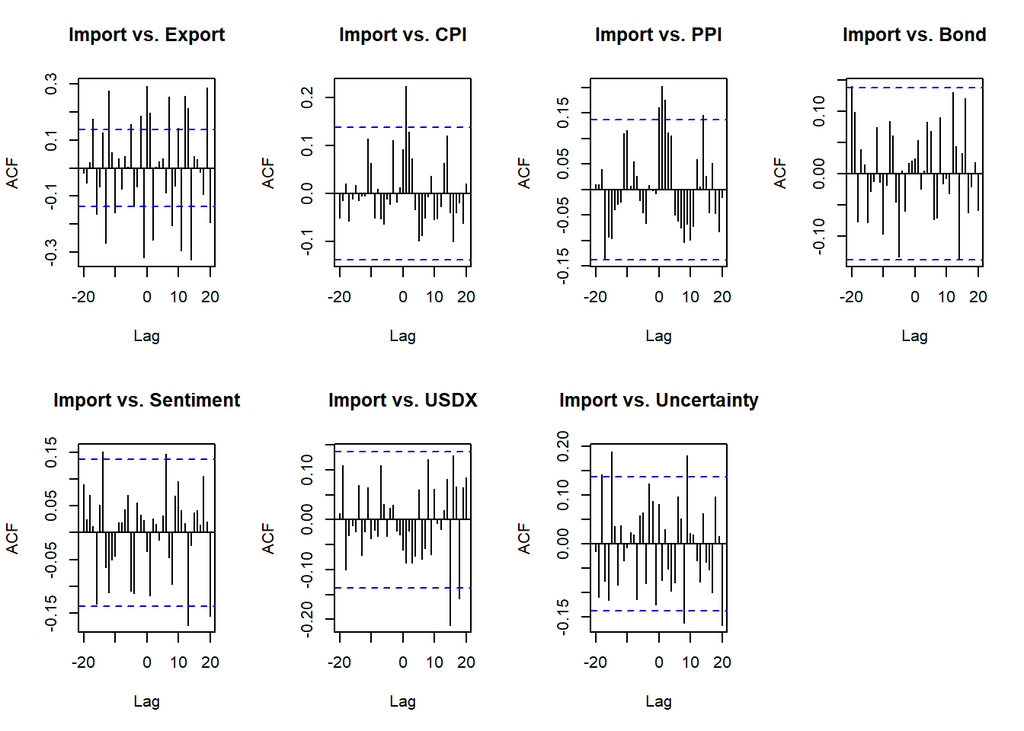

```r
par(mfrow = c(2, 4))
ccf(train_pre$import, train_pre$export, main = "Import vs. Export")
ccf(train_pre$import, train_pre$cpi, main = "Import vs. CPI")
ccf(train_pre$import, train_pre$ppi, main = "Import vs. PPI")
ccf(train_pre$import, train_pre$bond, main = "Import vs. Bond")
ccf(train_pre$import, train_pre$sentiment, main = "Import vs. Sentiment")
ccf(train_pre$import, train_pre$USDX, main = "Import vs. USDX")
ccf(train_pre$import, train_pre$uncertainty, main = "Import vs. Uncertainty")
```

*export* cpi: 1 sig lag *ppi: 4 sig lags* bond: 1 or 0 *sentiment: 4 sig lags* usdx: 2 sig lags *uncertainty: 4 sig lags

**Post-Covid:**

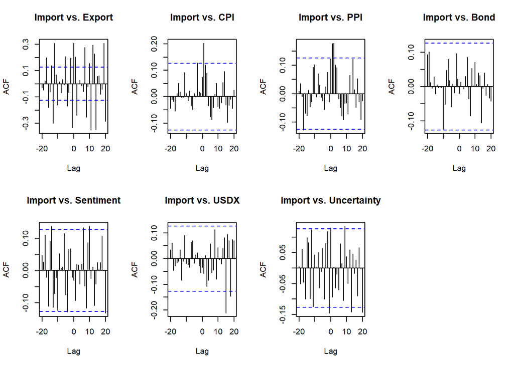

```r
par(mfrow = c(2, 4))
ccf(train_post$import, train_post$export, main = "Import vs. Export")
ccf(train_post$import, train_post$cpi, main = "Import vs. CPI")
ccf(train_post$import, train_post$ppi, main = "Import vs. PPI")
ccf(train_post$import, train_post$bond, main = "Import vs. Bond")
ccf(train_post$import, train_post$sentiment, main = "Import vs. Sentiment")
ccf(train_post$import, train_post$USDX, main = "Import vs. USDX")
ccf(train_post$import, train_post$uncertainty, main = "Import vs. Uncertainty")
```

## Granger Causality Test

**Pre-Covid:**

export + cpi + ppi

```r
variables <- c("export", "cpi", "ppi", "bond", "sentiment", "USDX", "uncertainty")

# Initialize the result matrices
granger_pre <- matrix(NA, nrow = length(variables), ncol = 4)

# Iterate over variables and perform grangertest
for (i in 1:length(variables)) {

  var_to_result <- grangertest(train_pre[[variables[i]]], train_pre$import, order = 1)
  impt_to_result <- grangertest(train_pre$import, train_pre[[variables[i]]], order = 1)

  var.impt.p <- round(var_to_result$`Pr(>F)`[2], digits = 5)
  var.impt.sig <- ifelse(var.impt.p < 0.05, "Caused", "Not Caused")
  impt.var.p <- round(impt_to_result$`Pr(>F)`[2], digits = 5)
  impt.var.sig <- ifelse(impt.var.p < 0.05, "Caused", "Not Caused")

  granger_pre[i, 1] <- var.impt.p
  granger_pre[i, 2] <- var.impt.sig
  granger_pre[i, 3] <- impt.var.p
  granger_pre[i, 4] <- impt.var.sig
}

# Set column names
colnames(granger_pre) <- c("var.impt.p", "var.impt.sig",
                        "impt.var.p", "impt.var.sig")


# Create data frames with variables, p-values, and significance
granger_pre <- data.frame(variables, granger_pre)
granger_pre
```

| variables | var.impt.p | var.impt.sig | impt.var.p | impt.var.sig |
| --- | --- | --- | --- | --- |
| export | 0.00012 | Caused | 0.00406 | Caused |
| cpi | 0.00045 | Caused | 0.67339 | Not Caused |
| ppi | 0.00064 | Caused | 0.25403 | Not Caused |
| bond | 0.41393 | Not Caused | 0.79439 | Not Caused |
| sentiment | 0.07318 | Not Caused | 0.74872 | Not Caused |
| USDX | 0.15754 | Not Caused | 0.70118 | Not Caused |
| uncertainty | 0.39899 | Not Caused | 0.12579 | Not Caused |

**Post-Covid**

export + cpi/ppi

```r
# Initialize the result matrices
granger_post <- matrix(NA, nrow = length(variables), ncol = 4)

# Iterate over variables and perform grangertest
for (i in 1:length(variables)) {

  var_to_result <- grangertest(train_post[[variables[i]]], train_post$import, order = 1)
  impt_to_result <- grangertest(train_post$import, train_post[[variables[i]]], order = 1)

  var.impt.p <- round(var_to_result$`Pr(>F)`[2], digits = 5)
  var.impt.sig <- ifelse(var.impt.p < 0.05, "Caused", "Not Caused")
  impt.var.p <- round(impt_to_result$`Pr(>F)`[2], digits = 5)
  impt.var.sig <- ifelse(impt.var.p < 0.05, "Caused", "Not Caused")

  granger_post[i, 1] <- var.impt.p
  granger_post[i, 2] <- var.impt.sig
  granger_post[i, 3] <- impt.var.p
  granger_post[i, 4] <- impt.var.sig
}

# Set column names
colnames(granger_post) <- c("var.impt.p", "var.impt.sig",
                        "impt.var.p", "impt.var.sig")


# Create data frames with variables, p-values, and significance
granger_post <- data.frame(variables, granger_post)
granger_post
```

| variables | var.impt.p | var.impt.sig | impt.var.p | impt.var.sig |
| --- | --- | --- | --- | --- |
| export | 1e-05 | Caused | 0.00076 | Caused |
| cpi | 0.00052 | Caused | 0.66247 | Not Caused |
| ppi | 0.00141 | Caused | 0.14998 | Not Caused |
| bond | 0.88486 | Not Caused | 0.64052 | Not Caused |
| sentiment | 0.1228 | Not Caused | 0.7456 | Not Caused |
| USDX | 0.31856 | Not Caused | 0.40884 | Not Caused |
| uncertainty | 0.27819 | Not Caused | 0.0706 | Not Caused |